# US Census analysis

### Imports

```python
%matplotlib inline
import pandas as pd
import seaborn as sns
import matplotlib.pyplot as plt

from sklearn.ensemble import RandomForestClassifier
from sklearn.linear_model import LogisticRegressionCV
from sklearn.svm import SVC

from sklearn.model_selection import cross_val_score
from sklearn.metrics import confusion_matrix
from sklearn.metrics import roc_curve, auc, f1_score
from time import time
```

## 1. Loading the data

The US Census dataset has 40 features, most of them categorical. Let us load the csv file into a pandas DataFrame to ease analysis and visualization.

```python
column_names = ['age',
       'class of worker',
       'industry code',
       'occupation code',
       'education',
       'wage per hour',
       'enrolled in edu inst last wk',
       'marital status',
       'major industry code',
       'major occupation code',
       'race',
       'hispanic Origin',
       'sex',
       'member of a labor union',
       'reason for unemployment',
       'full or part time employment stat',
       'capital gains',
       'capital losses',
       'dividends from stocks',
       'tax filer status',
       'region of previous residence',
       'state of previous residence',
       'detailed household and family stat',
       'detailed household summary in household',
       'instance weight',
       'migration code-change in msa',
       'migration code-change in reg',
       'migration code-move within reg',
       'live in this house 1 year ago',
       'migration prev res in sunbelt',
       'num persons worked for employer',
       'family members under 18',
       'country of birth father',
       'country of birth mother',
       'country of birth self',
       'citizenship',
       'own business or self employed',
       'fill inc questionnaire for veterans admin',
       'veterans benefits',
       'weeks worked in year',
       'year',
       'class'] # Class is our target feature (income <50000 or >50000)

data_train = pd.read_csv('census_income_learn.csv',\
                   names = column_names,
                  index_col = False )
data_test = pd.read_csv('census_income_test.csv',\
                   names = column_names,
                  index_col = False )

n_samples = len(data_train)
data_train.head(2)
```

|  | age | class of worker | industry code | occupation code | education | wage per hour | enrolled in edu inst last wk | marital status | major industry code | major occupation code | ... | country of birth father | country of birth mother | country of birth self | citizenship | own business or self employed | fill inc questionnaire for veterans admin | veterans benefits | weeks worked in year | year | class |
| --- | --- | --- | --- | --- | --- | --- | --- | --- | --- | --- | --- | --- | --- | --- | --- | --- | --- | --- | --- | --- | --- |
| 0 | 73 | Not in universe | 0 | 0 | High school graduate | 0 | Not in universe | Widowed | Not in universe or children | Not in universe | ... | United-States | United-States | United-States | Native- Born in the United States | 0 | Not in universe | 2 | 0 | 95 | - 50000. |
| 1 | 58 | Self-employed-not incorporated | 4 | 34 | Some college but no degree | 0 | Not in universe | Divorced | Construction | Precision production craft & repair | ... | United-States | United-States | United-States | Native- Born in the United States | 0 | Not in universe | 2 | 52 | 94 | - 50000. |

2 rows × 42 columns

## 2. Preliminary analysis

### 2.1 Missing values

Before analyzing the data, we must clean it. The missing values in the dataset are marked by *' ?'* and not by the default *nan*. Hence to identify the proportion of missing data for each column, we must find the occurences of *' ?'*.

```python
# Example feature with missing values
data_train['migration code-change in msa'].unique()
```

```
array([' ?', ' MSA to MSA', ' Nonmover', ' NonMSA to nonMSA',
       ' Not in universe', ' Not identifiable', ' Abroad to MSA',
       ' MSA to nonMSA', ' Abroad to nonMSA', ' NonMSA to MSA'], dtype=object)
```

```python
# Training set
for c in column_names:
    s = data_train[c].value_counts()
    if ' ?' in s.index:
        d = dict(s)
        print('Column %s contains %.2f %% missing values' % (c, d[' ?']/n_samples * 100))
```

```
Column state of previous residence contains 0.35 % missing values
Column migration code-change in msa contains 49.97 % missing values
Column migration code-change in reg contains 49.97 % missing values
Column migration code-move within reg contains 49.97 % missing values
Column migration prev res in sunbelt contains 49.97 % missing values
Column country of birth father contains 3.36 % missing values
Column country of birth mother contains 3.07 % missing values
Column country of birth self contains 1.70 % missing values
```

```python
# Test set
for c in column_names:
    s = data_test[c].value_counts()
    if ' ?' in s.index:
        d = dict(s)
        print('Column %s contains %.2f %% missing values' % (c, d[' ?']/n_samples * 100))
```

```
Column state of previous residence contains 0.17 % missing values
Column migration code-change in msa contains 25.03 % missing values
Column migration code-change in reg contains 25.03 % missing values
Column migration code-move within reg contains 25.03 % missing values
Column migration prev res in sunbelt contains 25.03 % missing values
Column country of birth father contains 1.72 % missing values
Column country of birth mother contains 1.54 % missing values
Column country of birth self contains 0.88 % missing values
```

We can see here that the four features concerning migration have 50% of missing values in the training set. For our analysis we will not consider those features.

The other features have a negligeable amount of missing values with respect to the overall number of samples, so we can choose to drop the corresponding rows.

```python
# Ignore rows with remaining missing values
cleaned_data = data_train[data_train['state of previous residence']!=' ?']
cleaned_data = cleaned_data[cleaned_data['country of birth father']!=' ?']
cleaned_data = cleaned_data[cleaned_data['country of birth mother']!=' ?']
cleaned_data = cleaned_data[cleaned_data['country of birth self']!=' ?'].reset_index(drop=True)

n_csamples = len(cleaned_data)
```

```python
print('Train data with missing values has %d rows' % (len(data_train)))
p = (len(data_train)- len(cleaned_data))/len(data_train)
print('Train data with no missing values has %d rows (%.2f %% less)' % (len(cleaned_data), p*100))
```

```
Train data with missing values has 199523 rows
Train data with no missing values has 190561 rows (4.49 % less)
```

### 2.2 Class balance

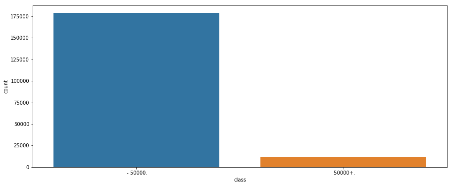

```python
plt.figure(figsize=(15,6))
sns.countplot(x = cleaned_data['class']);
```

We can see that the classes in our data are highly imbalanced. From the metadata file, we know that the test set presents the same ratio. This will be a problem when constructing our predictive model. We would need to perform some transformations in the dataset to reduce this skew, such as oversampling of minority class and/or undersampling the majority class. Moreover, we would need to adapt our metrics since the predictive accuracy will not be informative (a classifier that outputs predicts only class 0 will have 95% accuracy with our test set).

For convenience, we are going to replace the class labels by -1 and 1.

```python
# Let us change those class labels into 0 and 1
def change_label(cl):
    if cl==' - 50000.':
        cl = -1
    else:
        cl = 1
    return int(cl)
labels_train = cleaned_data['class'].map(change_label)
cleaned_data = pd.concat([cleaned_data.drop('class',axis=1),\
                          pd.DataFrame(labels_train, columns=['class'])],axis=1)

labels_test = data_test['class'].map(change_label)
data_test = pd.concat([data_test.drop('class',axis=1),\
                       pd.DataFrame(labels_test, columns=['class'])],axis=1)
```

### 2.3 Univariate statistics: continuous variables

```python
continuous = [column_names[i] for i in [0, 5, 16, 17, 18, 30, 39]]
print(continuous)
```

```
['age', 'wage per hour', 'capital gains', 'capital losses', 'dividends from stocks', 'num persons worked for employer', 'weeks worked in year']
```

#### a) Age

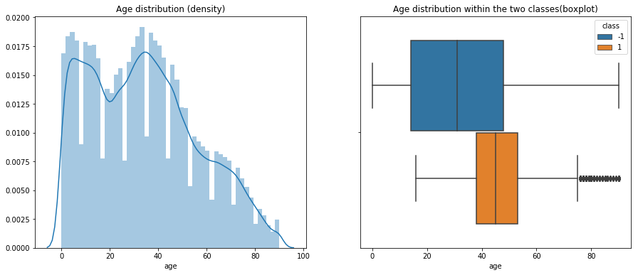

```python
plt.figure(figsize=(15,6))
plt.subplot(121)
plt.title('Age distribution (density)')
sns.distplot(cleaned_data[continuous[0]])
plt.subplot(122)
sns.boxplot(x=cleaned_data['age'],y=[""]*n_csamples,hue=cleaned_data['class'])
plt.title('Age distribution within the two classes(boxplot)')
plt.show()
```

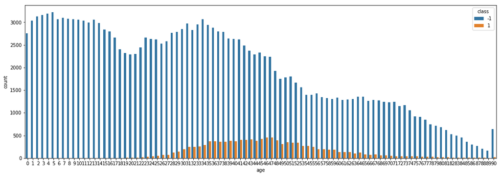

```python
plt.figure(figsize=(18,6))
sns.countplot(x=cleaned_data['age'],hue=cleaned_data['class']);
```

```python
print('%.2f %% of samples are children' %(cleaned_data[cleaned_data['age']<16].count()[1]/n_csamples*100))
```

```
25.60 % of samples are children
```

The following four features concern the financial situation of a person. We will represent those with a scatter plot to visualize at which levels the different classes are concentrated.

#### b) Wage per hour

```python
# Define new dataframe with an index column for visualization with seaborn lmplot
cd_widx = cleaned_data.copy()
index = pd.Series(cleaned_data.index, dtype=np.int)
idx_column = pd.DataFrame(index,columns=['index'])
cd_widx = pd.concat([idx_column, cd_widx],axis=1)
```

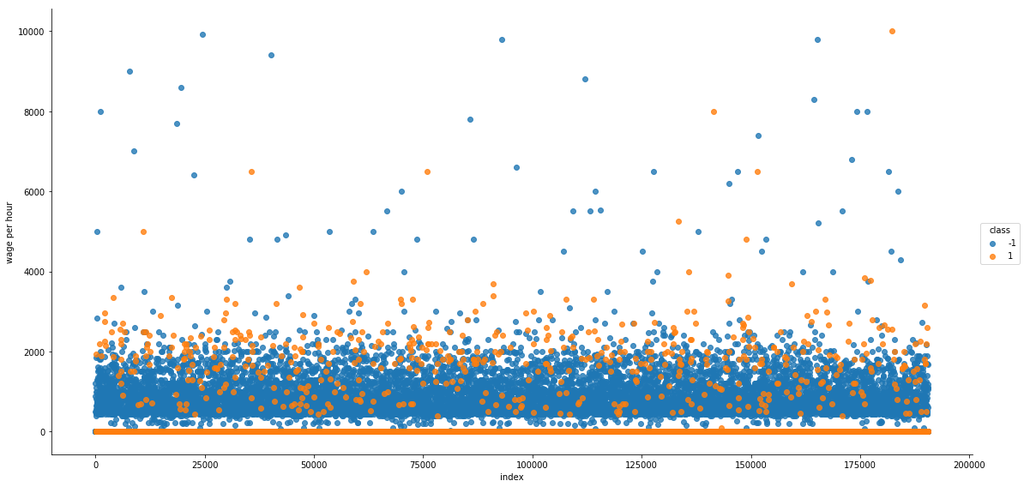

```python
sns.lmplot(x='index',y=continuous[1], data=cd_widx, hue='class', fit_reg=False, size=8, aspect=2)
plt.show()
```

```python
s = dict(cleaned_data[cleaned_data['wage per hour']==0]['class'].value_counts())
#print(s)
print('%.2f %% of samples have a wage per hour of 0 but are in class -1' % (s[-1]/(n_csamples)*100))
print('%.2f %% of samples have a wage per hour of 0 but are in class 1' % (s[1]/(n_csamples)*100))
```

```
88.42 % of samples have a wage per hour of 0 but are in class -1
5.84 % of samples have a wage per hour of 0 but are in class 1
```

How can we interpret the value of 0 for this feature? There can be various reasons: we can be talking about a child, a retiree. Since it is a numerical feature it is possible that some of the 0 represent an unknown value.

In fact more than 90% of our dataset has wage per hour of 0. Let us look at the remaining entries.

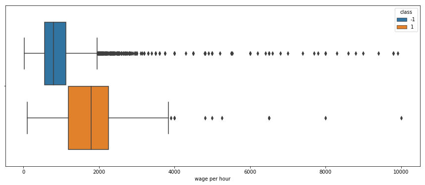

```python
plt.figure(figsize=(15,6))
tmp = cleaned_data[cleaned_data['wage per hour']!=0]
sns.boxplot(x=tmp['wage per hour'],y=[""]*len(tmp),hue=tmp['class']);
```

As we can see, the remaining values are more representative of the two classes. Unsurprisingly, peope having a high amount of wage per hour tend to be in class 1. Once again this feature will be interesting to keep, as it is of transformed.

#### c) Capital gains, capital losses, dividends from stocks

Capital gains and losses are complementary information.

```python
print(cleaned_data[cleaned_data['capital gains']>0]['capital losses'].value_counts())
print(cleaned_data[cleaned_data['capital losses']>0]['capital gains'].value_counts())
```

```
0    6938
Name: capital losses, dtype: int64
0    3696
Name: capital gains, dtype: int64
```

The two features are mutually exclusive. One who has gains has no losses and vice versa. Thus we can construct a new feature, allowing negative values for losses. By substracting the loss column to the gain column, we will simplify the data by reducing the number of features by 1, without losing any information.

```python
cap_column = pd.DataFrame(cleaned_data['capital gains'] - cleaned_data['capital losses'],
                          columns=['capital gain/loss'])
cleaned_data = cleaned_data.drop(['capital gains'], axis=1)
cleaned_data = cleaned_data.drop(['capital losses'], axis=1)
cleaned_data = pd.concat([cleaned_data, cap_column], axis=1)

cap_column = pd.DataFrame(data_test['capital gains'] - data_test['capital losses'],
                          columns=['capital gain/loss'])
data_test = data_test.drop(['capital gains'], axis=1)
data_test = data_test.drop(['capital losses'], axis=1)
data_test = pd.concat([data_test, cap_column], axis=1)


cleaned_data.head(1)
```

|  | age | class of worker | industry code | occupation code | education | wage per hour | enrolled in edu inst last wk | marital status | major industry code | major occupation code | ... | country of birth mother | country of birth self | citizenship | own business or self employed | fill inc questionnaire for veterans admin | veterans benefits | weeks worked in year | year | class | capital gain/loss |
| --- | --- | --- | --- | --- | --- | --- | --- | --- | --- | --- | --- | --- | --- | --- | --- | --- | --- | --- | --- | --- | --- |
| 0 | 73 | Not in universe | 0 | 0 | High school graduate | 0 | Not in universe | Widowed | Not in universe or children | Not in universe | ... | United-States | United-States | Native- Born in the United States | 0 | Not in universe | 2 | 0 | 95 | -1 | 0 |

1 rows × 41 columns

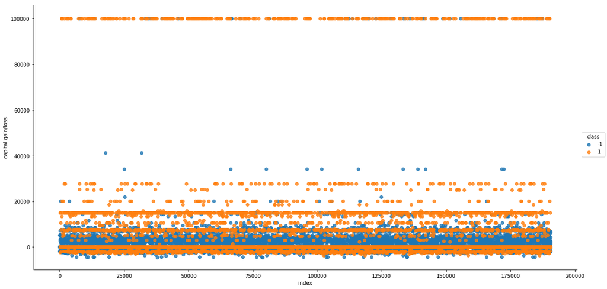

```python
# Define new dataframe with an index column for visualization with seaborn lmplot
cd_widx = cleaned_data.copy()
index = pd.Series(cleaned_data.index, dtype=np.int)
idx_column = pd.DataFrame(index,columns=['index'])
cd_widx = pd.concat([idx_column, cd_widx],axis=1)

sns.lmplot(x='index',y='capital gain/loss', data=cd_widx, hue='class', fit_reg=False, size=8, aspect=2)
plt.show()
```

```python
s = dict(cleaned_data[cleaned_data['capital gain/loss']==0]['class'].value_counts())
#print(s)
print('%.2f %% of samples have a capital gain/loss of 0 but are in class -1' % (s[-1]/(n_csamples)*100))
print('%.2f %% of samples have a capital gain/loss of 0 but are in class 1' % (s[1]/(n_csamples)*100))
```

```
90.06 % of samples have a capital gain/loss of 0 but are in class -1
4.36 % of samples have a capital gain/loss of 0 but are in class 1
```

Note that for all these 4 features there is a solid line of points at 0, since there are many children in the dataset, and they are not concerned. To gain more insight on the discriminative power, we look at the distribution of the values which are different from 0.

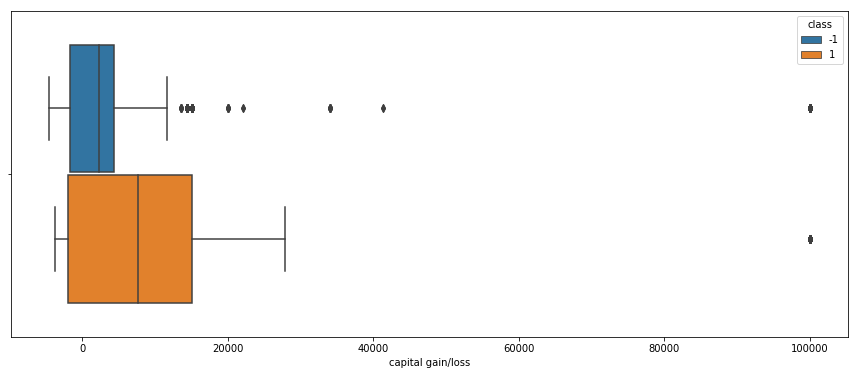

```python
plt.figure(figsize=(15,6))
tmp = cleaned_data[cleaned_data['capital gain/loss']!=0]
sns.boxplot(x=tmp['capital gain/loss'],y=[""]*len(tmp),hue=tmp['class']);
```

Instances from the high income class have bigger average capital gains than the others. We will keep this feature for our analysis.

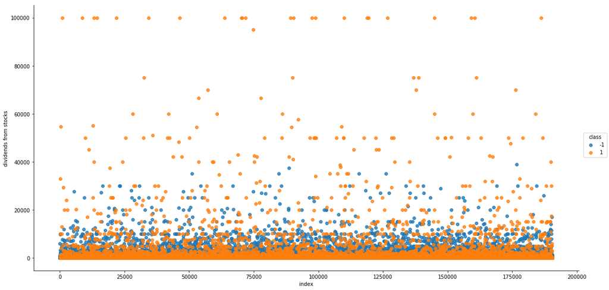

```python
sns.lmplot(x='index',y=continuous[4], data=cd_widx, hue='class', fit_reg=False, size=8, aspect=2)
plt.show()
```

```python
s = dict(cleaned_data[cleaned_data['dividends from stocks']==0]['class'].value_counts())
#print(s)
print('%.2f %% of samples have dividends from stocks of 0 but are in class -1' % (s[-1]/(n_csamples)*100))
print('%.2f %% of samples have dividends from stocks of 0 but are in class 1' % (s[1]/(n_csamples)*100))
```

```
86.07 % of samples have dividends from stocks of 0 but are in class -1
3.50 % of samples have dividends from stocks of 0 but are in class 1
```

As for capital gain/loss, this feature seems to caracterise class 1 in some way: in fact above a certain amount, say 30000, we have almost exclusively class 1 instances.

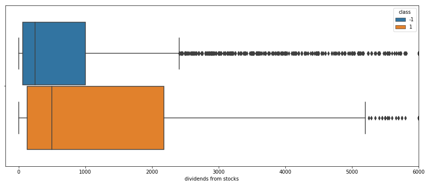

```python
plt.figure(figsize=(15,6))
tmp = cleaned_data[cleaned_data['dividends from stocks']!=0]
sns.boxplot(x=tmp['dividends from stocks'],y=[""]*len(tmp),hue=tmp['class'])
plt.xlim([-200, 6000])
plt.show()
```

Once again, instances from the high income class have values for this feature than the others.

#### d) Num persons worked for employer, weeks worked in year

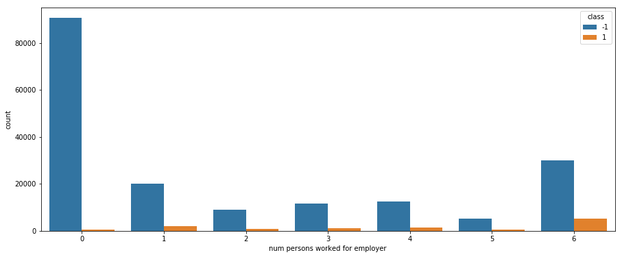

```python
plt.figure(figsize=(15,6))
sns.countplot(x=cleaned_data[continuous[5]],hue=cleaned_data['class'])
plt.show()
```

This feature does not seem to be extremely informative regarding the income. The ratio of class -1 and 1 seems to be quite similar for all values except 0.

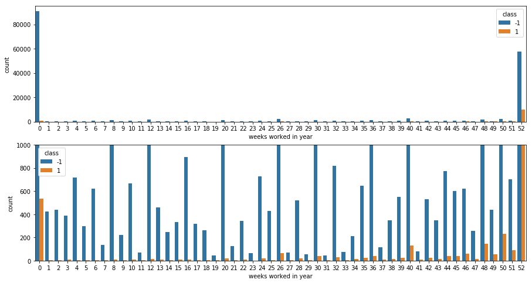

```python
plt.figure(figsize=(15,8))
plt.subplot(211)
sns.countplot(x=cleaned_data[continuous[6]],hue=cleaned_data['class'])
plt.subplot(212)
sns.countplot(x=cleaned_data[continuous[6]],hue=cleaned_data['class'])
plt.ylim([0,1000])
plt.show()
```

Here we made a zoom on the second bar plot, to notice that unsurprisingly people from class 1 seem to work more weeks in a year. However this feature is less discriminative for the class -1 instances, and we have outliers that worked 0 weeks in a year.

### 2.3 Univariate statistics: nominal variables

An interesting fact to notice is that we have a lot of categorical features, and most of them do not concern every person in our dataset. This is denoted by the instance 'Not in universe': an obvious example, if we have a child, he/she will probably not be concerned by the feature 'member of a labor union'.

```python
nominal = [col for col in column_names if col not in continuous][:-1]
print('%d categorical features:\n ' %(len(nominal)), nominal)
```

```
34 categorical features:
  ['class of worker', 'industry code', 'occupation code', 'education', 'enrolled in edu inst last wk', 'marital status', 'major industry code', 'major occupation code', 'race', 'hispanic Origin', 'sex', 'member of a labor union', 'reason for unemployment', 'full or part time employment stat', 'tax f…
```

```python
# Instance weight is ignored as indicated in the meta data file
# Features concerning migration are ignored since half of the values are missing
# We are left with 29 features that we can regroup in different categories

work_features = ['class of worker',
                 'member of a labor union',
                 'industry code',
                 'occupation code',
                 'major industry code',
                 'major occupation code',
                 'reason for unemployment',
                 'full or part time employment stat',
                 'own business or self employed']

origin_features = ['race',
                   'hispanic Origin',
                   'country of birth father',
                   'country of birth mother',
                   'country of birth self']

about_features = ['education',
                  'enrolled in edu inst last wk',
                  'marital status',
                  'sex',
                  'citizenship',
                  'region of previous residence',
                  'state of previous residence']

admin_features = ['tax filer status',
                  'detailed household and family stat',
                  'detailed household summary in household',
                  'live in this house 1 year ago']

misc_features =  ['fill inc questionnaire for veterans admin',
                 'veterans benefits',
                 'year']
```

```python
# Define a function to get a bar plot on the population concerned by a given feature

def get_stats(feature):
    s = dict(cleaned_data[feature].value_counts())
    t = False

    # Extract proportion of not in universe
    if feature=='major industry code':
        if ' Not in universe or children' in s.keys():
            t = True
            p = s[' Not in universe or children'] / n_csamples * 100
            nu_stats = \
            cleaned_data[cleaned_data[feature]==' Not in universe or children']['class'].value_counts()
            tmp = cleaned_data[cleaned_data[feature]!=' Not in universe or children']
        else:
            tmp = cleaned_data

    elif feature=='live in this house 1 year ago':
        if ' Not in universe under 1 year old' in s.keys():
            t = True
            p = s[' Not in universe under 1 year old'] / n_csamples * 100
            tmp = cleaned_data[cleaned_data[feature]!=' Not in universe under 1 year old']
            nu_stats = \
            cleaned_data[cleaned_data[feature]==' Not in universe under 1 year old']['class'].value_counts()
        else:
            tmp = cleaned_data

    else:
        if ' Not in universe' in s.keys():
            t = True
            p = s[' Not in universe'] / n_csamples * 100
            nu_stats = \
            cleaned_data[cleaned_data[feature]==' Not in universe']['class'].value_counts()
            tmp = cleaned_data[cleaned_data[feature]!=' Not in universe']
        else:
            tmp = cleaned_data


    # Plot distribution of remaining instances
    plt.figure(figsize=(15,6))
    if t:
        plt.title('%s, concerns %.2f %% of total samples (the rest not in universe)' %(feature, 100 - p))
    else:
        plt.title('%s' %(feature))
    sns.countplot(y=tmp[feature], hue=tmp['class'], order =\
             tmp[feature].value_counts().index)
    plt.show()

    # Print information about classes in the not in universe category
    if t:
        s = dict(nu_stats)
        s_total = dict(cleaned_data['class'].value_counts())
        s[-1] = s[-1]/s_total[-1]*100
        s[1] = s[1]/s_total[1]*100
        print('Ratio of classes for not in universe')
        print('Class -1: %.2f %% of total representatives not in universe for this feature' %(s[-1]))
        print('Class 1: %.2f %% of total representatives not in universe for this feature' %(s[1]))
        print('-----------------------------------------------------------------------------------')
    pass
```

#### a) Work related features

```python
print(work_features)
```

```
['class of worker', 'member of a labor union', 'industry code', 'occupation code', 'major industry code', 'major occupation code', 'reason for unemployment', 'full or part time employment stat', 'own business or self employed']
```

Let us first examine industry/occupation code and major industry/major occupation code features. We can imagine that the first couple is a detailed version of the second, since the cardinalities are higher.

```
industry code: 50 % of samples with code 0
within this portion of the population,
- the major industry code is  Not in universe or children
- the major occupation code is  Not in universe
- the occupation code is 0
------------------------------
occupation code: 50 % of samples with code 0
within this portion of the population,
- the major industry code is  Not in universe or children
- the major occupation code is  Not in universe
- the occupation code is 0
```

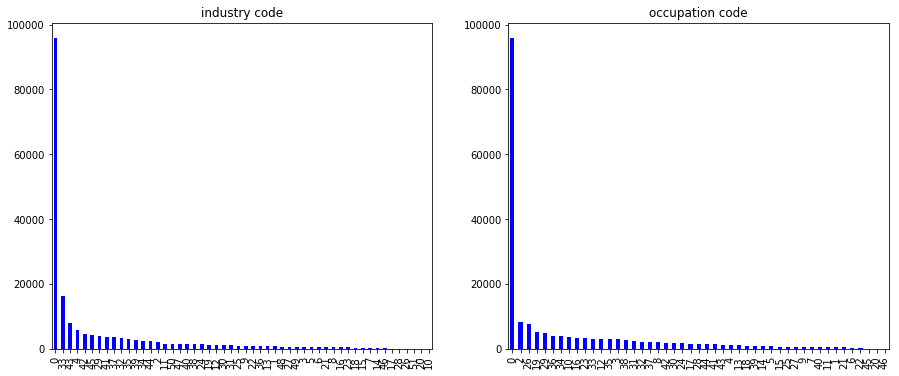

```python
plt.subplot(121)
plt.title('industry code')
s = cleaned_data['industry code'].value_counts()
print('industry code: %2.f %% of samples with code 0'%(dict(s)[0]/n_csamples*100))
tmp = cleaned_data[cleaned_data['industry code']==0]['major industry code'].value_counts().index[0]
print('within this portion of the population,\n- the major industry code is', tmp)
tmp = cleaned_data[cleaned_data['industry code']==0]['major occupation code'].value_counts().index[0]
print('- the major occupation code is', tmp)
tmp = cleaned_data[cleaned_data['industry code']==0]['occupation code'].value_counts().index[0]
print('- the occupation code is', tmp)
print('------------------------------')
s.plot('bar', figsize=(15,6),color='blue')
plt.subplot(122)
plt.title('occupation code')
s = cleaned_data['occupation code'].value_counts()
print('occupation code: %2.f %% of samples with code 0'%(dict(s)[0]/n_csamples*100))
tmp = cleaned_data[cleaned_data['occupation code']==0]['major industry code'].value_counts().index[0]
print('within this portion of the population,\n- the major industry code is', tmp)
tmp = cleaned_data[cleaned_data['occupation code']==0]['major occupation code'].value_counts().index[0]
print('- the major occupation code is', tmp)
tmp = cleaned_data[cleaned_data['occupation code']==0]['industry code'].value_counts().index[0]
print('- the occupation code is', tmp)
s.plot('bar', figsize=(15,6),color='blue')
plt.show()
```

So we see here that there is a tight relationship between industry code, occupation code, major industry code, major occupation code features. In the first couple, a code of 0 corresponds to 'Not in universe' for the second couple. Thus for simplification purposes we will only examine the major codes, potential features to be fed to the model.

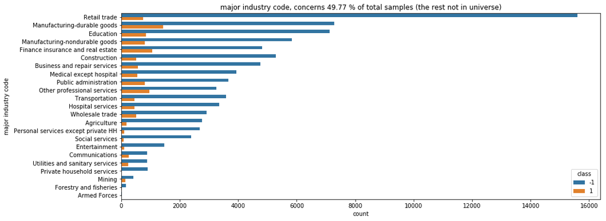

```
Ratio of classes for not in universe
Class -1: 53.05 % of total representatives not in universe for this feature
Class 1: 7.04 % of total representatives not in universe for this feature
-----------------------------------------------------------------------------------
```

```python
get_stats('major industry code')
```

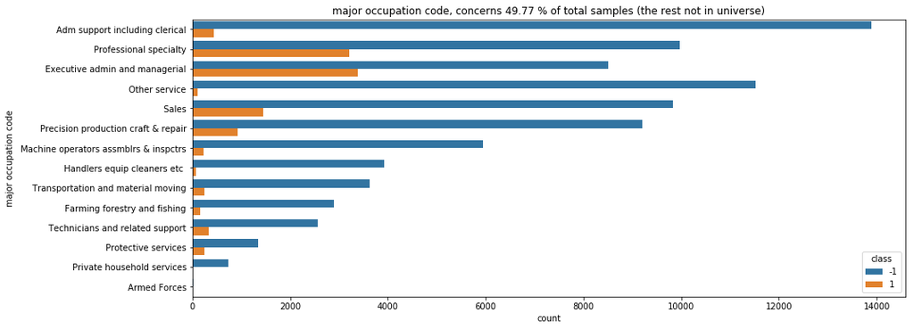

```
Ratio of classes for not in universe
Class -1: 53.05 % of total representatives not in universe for this feature
Class 1: 7.04 % of total representatives not in universe for this feature
-----------------------------------------------------------------------------------
```

```python
get_stats('major occupation code')
```

Most of the instances of class 1 in our data are concerned by this feature, thus it has a certain discriminative power that can be useful for our model. We will try to keep only one or both, and see how it impacts the results.

Let us examine the remaining work related features

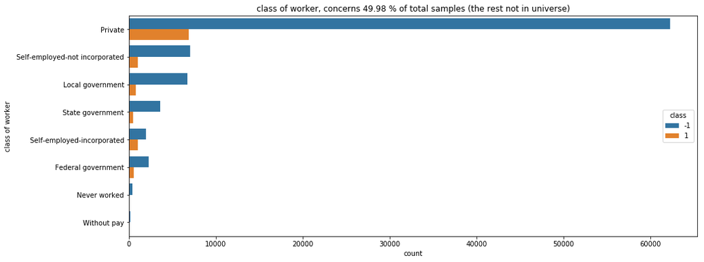

```
Ratio of classes for not in universe
Class -1: 52.82 % of total representatives not in universe for this feature
Class 1: 7.04 % of total representatives not in universe for this feature
-----------------------------------------------------------------------------------
```

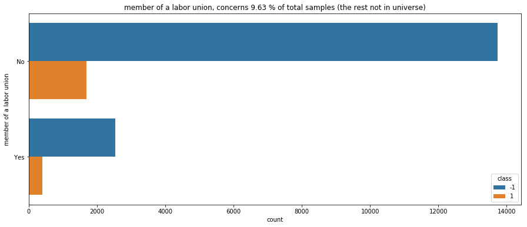

```
Ratio of classes for not in universe
Class -1: 90.91 % of total representatives not in universe for this feature
Class 1: 82.08 % of total representatives not in universe for this feature
-----------------------------------------------------------------------------------
```

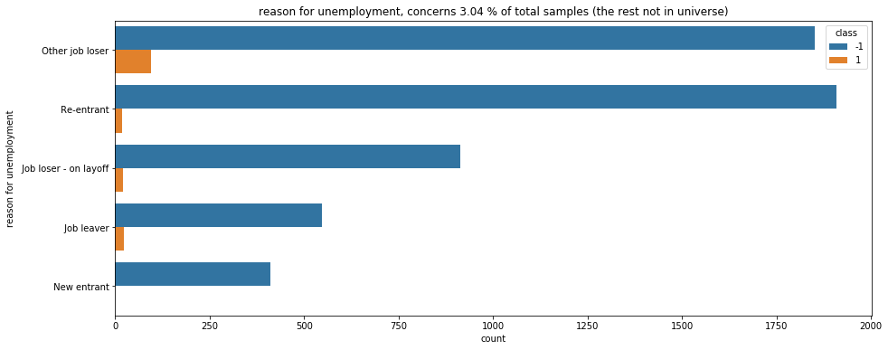

```
Ratio of classes for not in universe
Class -1: 96.85 % of total representatives not in universe for this feature
Class 1: 98.67 % of total representatives not in universe for this feature
-----------------------------------------------------------------------------------
```

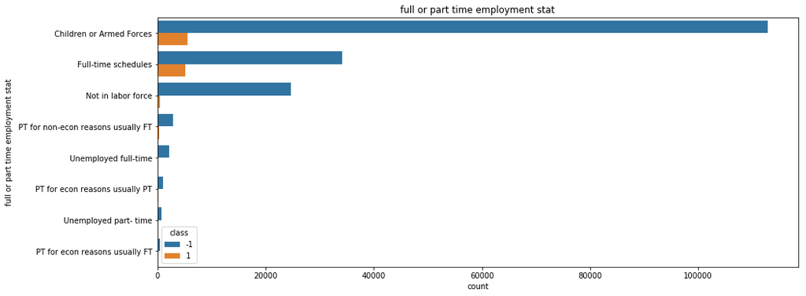

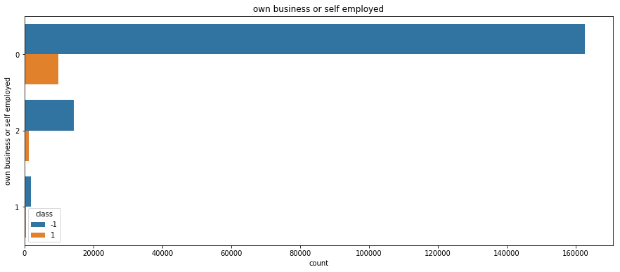

```python
for f in work_features:
    if f not in ['major occupation code', 'occupation code', 'industry code','major industry code']:
        get_stats(f)
```

As above, 'class of worker' seems to be an interesting feature for caracterizing our minority class, in the sense that most of them are concerned by this feature whereas 50% of the class -1 representatives are not.

Afterwards, we can see that 'member of labor union' and 'reason for unemployment' concern really a very small portion of both our instances, so we will not keep them as features to feed in our model.

Class 1 seems to be caracterized by 'Children or Armed Forces' and 'Full-Time schedulers' values for the 'full time employment stat. However this two values concern the majority of instances of class -1, so it may not be beneficial to keep this feature.

Finally most of the instances have a value of 0 for 'own business or self employed' feature. It does not seem to be discriminative since the great majority in each distinct values are instances of class -1. We will not keep this feature.

#### b) Origin features

```python
print(origin_features)
```

```
['race', 'hispanic Origin', 'country of birth father', 'country of birth mother', 'country of birth self']
```

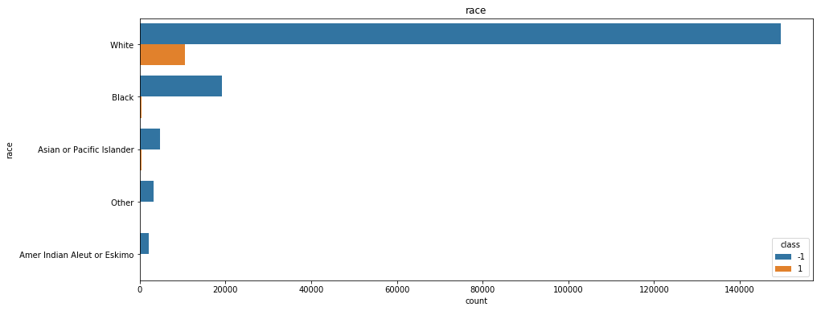

```python
get_stats('race')
```

The majority color in our data set is white, followed by black. High income people seem to be essentially white, which given the history of United States maybe not so surprising. We will keep this feature in a simplified binary version, white or not.

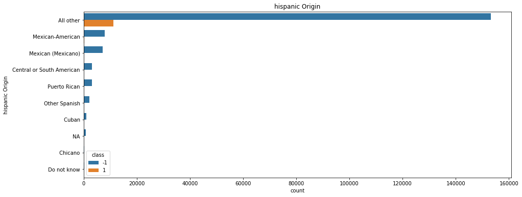

```python
get_stats('hispanic Origin')
```

Once again most of the class 1 instances are in the 'All other' category. Since the majority of class -1 is in there too, this feature has weak associations with income, thus we can ignore it in our treatment.

The next three features have the same cardinalities and the same distinct countries.

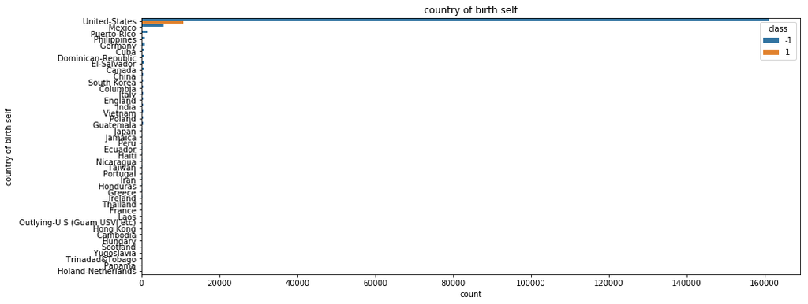

```python
get_stats('country of birth self')
```

We took 'self' as an example to show that these features are heavily skewed since most of the population have the country 'United States' in this three fields. Let us zoom in on te left part of the plot.

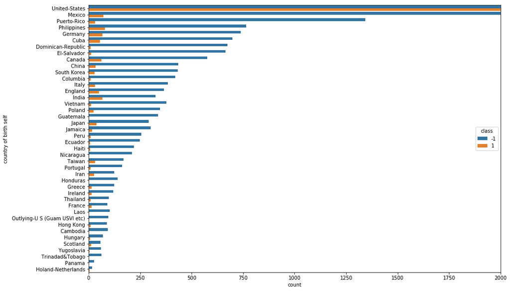

```python
plt.figure(figsize=(15,10))
sns.countplot(y=cleaned_data['country of birth self'],hue=cleaned_data['class'] ,order =\
             cleaned_data['country of birth self'].value_counts().index)
plt.xlim([0, 2000])
plt.show()
```

We can see that the country has also a weak relationship with income, the proportion of people coming from other places than united states is minimal regarding the dataset. There are some countries like Dominican-Republic or El-Salvador which have a much bigger proportion of class 0 than class 1. We can extract a list of countries which we assume caracterize mostly class 0.

```python
d1 = cleaned_data[cleaned_data['class']==1]['country of birth self'].value_counts().index
d2 = cleaned_data[cleaned_data['class']==-1]['country of birth self'].value_counts().index

for c in list(d2):
    if c not in list(d1):
        print(c)
```

```
 Trinadad&Tobago
 Panama
```

There are only two countries where class 1 is not represented, but since the overall instances from this country are very few, we can assume that this is a result of the 95%/5% ratio of classes. So we will not consider this features.

```python
for f in ['country of birth self', 'country of birth mother', 'country of birth father']:
    s = dict(cleaned_data[f].value_counts())
    print('%s : %.2f %% from United States' % (f,s[' United-States']/n_csamples*100 ))
```

```
country of birth self : 90.20 % from United States
country of birth mother : 83.17 % from United States
country of birth father : 82.72 % from United States
```

#### c) About features

```python
print(about_features)
```

```
['education', 'enrolled in edu inst last wk', 'marital status', 'sex', 'citizenship', 'region of previous residence', 'state of previous residence']
```

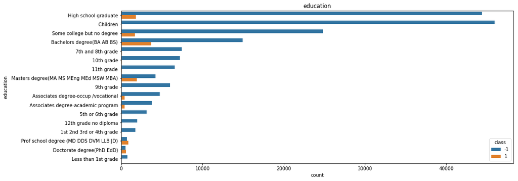

```python
get_stats('education')
```

We can see that some education types have a high proportion of class 1: Masters degree, Prof school degree and Doctorate degree, three high level education statuses. We can also include Bachelor's degree. We will keep this feature in a simplified binary form: 1 if the value is one of the elements mentionned above, -1 else.

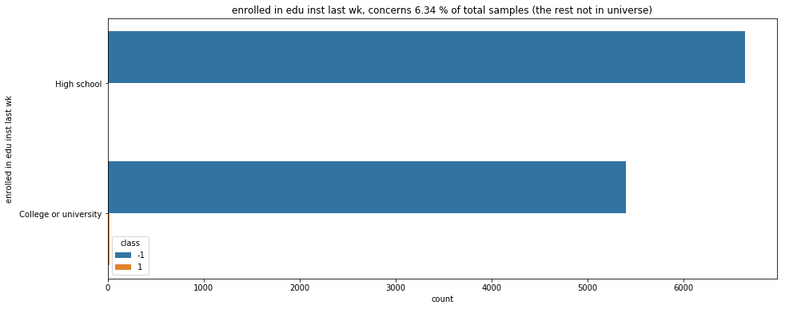

```
Ratio of classes for not in universe
Class -1: 93.27 % of total representatives not in universe for this feature
Class 1: 99.78 % of total representatives not in universe for this feature
-----------------------------------------------------------------------------------
```

```python
get_stats('enrolled in edu inst last wk')
```

Most of our data set is not concerned by this feature, so we will ignore it.

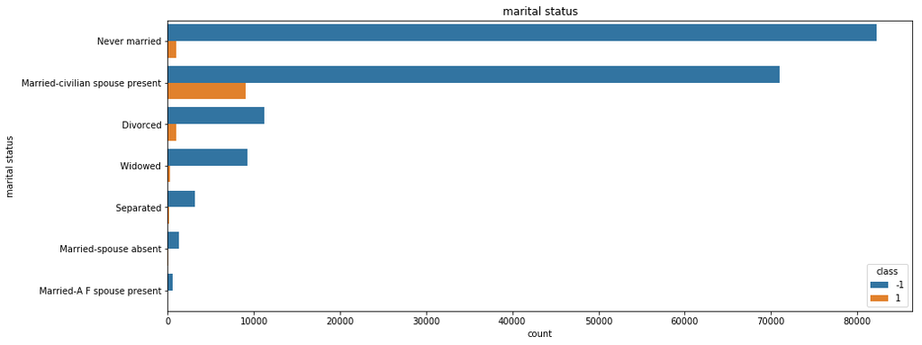

```python
get_stats('marital status')
```

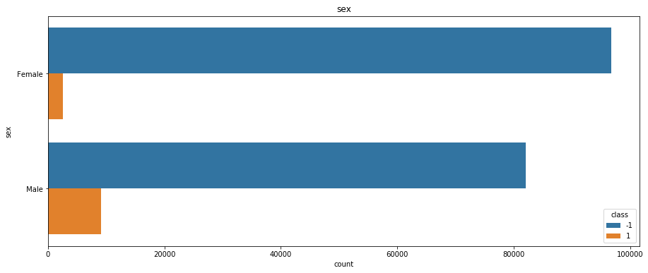

```python
get_stats('sex')
```

Knowing the gender wage gap reality, we can see that the Male category has more instances in class 1 than the Female category, thus we will keep this feature.

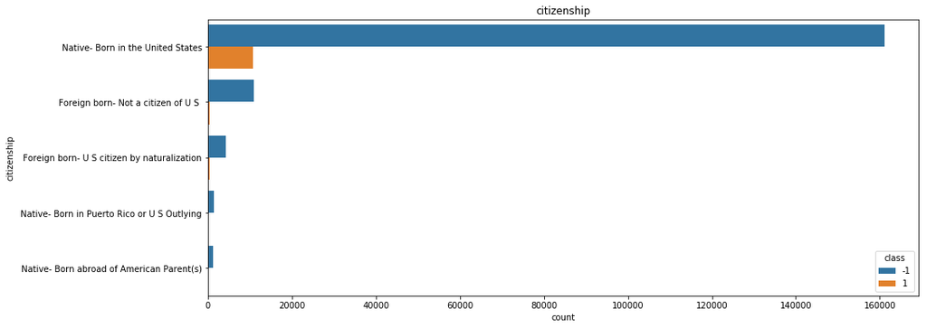

```python
get_stats('citizenship')
```

```python
cleaned_data[cleaned_data['country of birth self']==' United-States']['citizenship'].value_counts()
```

```
 Native- Born in the United States    171878
Name: citizenship, dtype: int64
```

As we can see this feature is related to 'country of birth self' and the interesting information is binary: native-born in US or no (which corresponds to country of birth self = United-States). Since we decided to not keep the three country of birth features, we can in fact combine them with this one to obtain an interesting information, which basically is 'Native US citizen or not'.

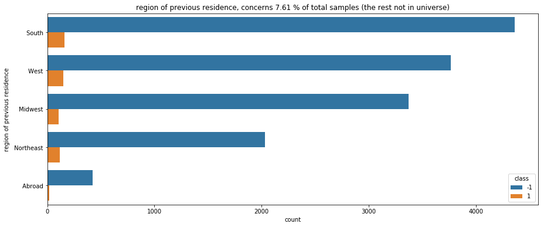

```
Ratio of classes for not in universe
Class -1: 92.20 % of total representatives not in universe for this feature
Class 1: 95.27 % of total representatives not in universe for this feature
-----------------------------------------------------------------------------------
```

```python
get_stats('region of previous residence')
```

Most of the data is not concerned by this feature. As we can see class 1 is almost equally distributed, thus the feature is non informative, we will ignore it.

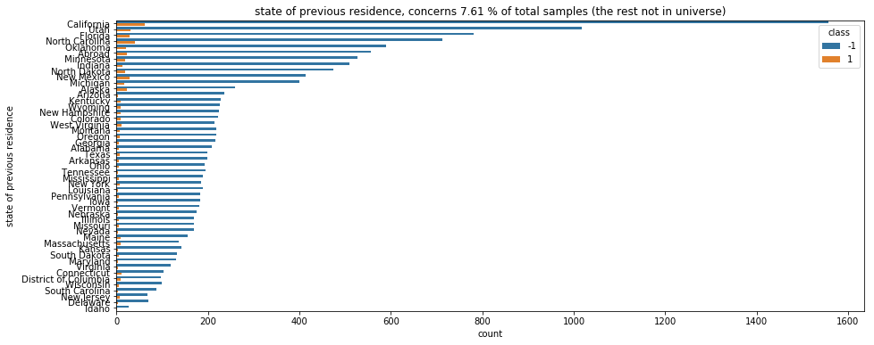

```
Ratio of classes for not in universe
Class -1: 92.20 % of total representatives not in universe for this feature
Class 1: 95.27 % of total representatives not in universe for this feature
-----------------------------------------------------------------------------------
```

```python
get_stats('state of previous residence')
```

Same remark, since the feature concerns only 8% of the data, we choose to ignore it.

#### d) Admin features

```python
print(admin_features)
```

```
['tax filer status', 'detailed household and family stat', 'detailed household summary in household', 'live in this house 1 year ago']
```

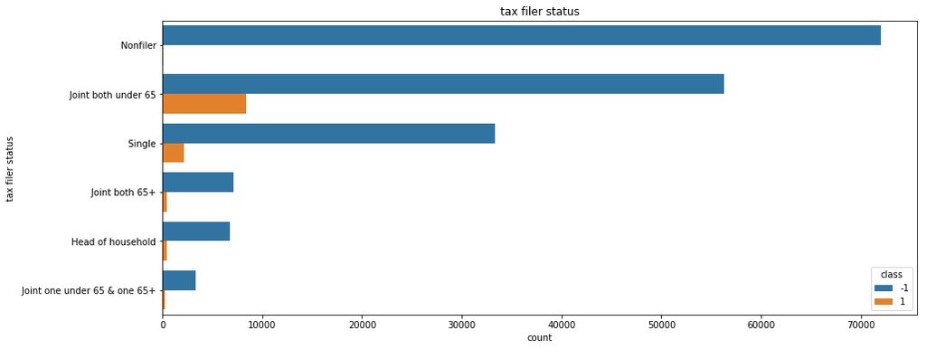

```python
get_stats('tax filer status')
```

We can summerize this feature, turning it into a binary 'Nonfiler or not', since the 'Nonfiler' field caracterizes class 0.

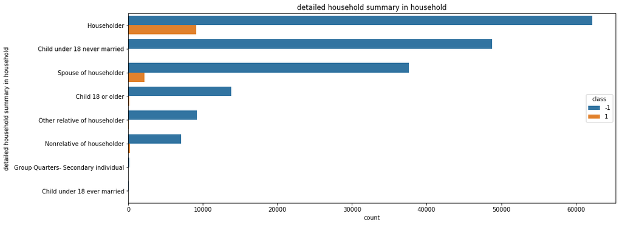

```python
get_stats('detailed household summary in household')
```

We can ignore the detailed version of the feature above, since the summary supplies us enough information. In fact, class 1 seem to be householders or people connected to a householder. Thus we can simplify this feature into a binary one: group Householder, Spouse of householder, Nonrelative of householder on one side, and the rest on the other.

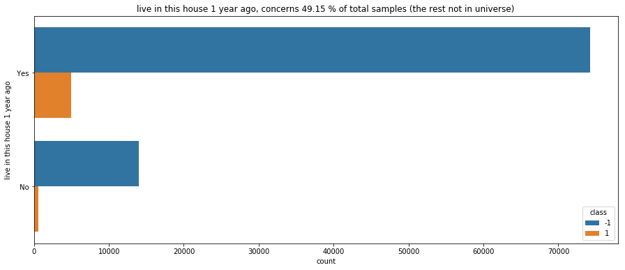

```
Ratio of classes for not in universe
Class -1: 50.71 % of total representatives not in universe for this feature
Class 1: 53.00 % of total representatives not in universe for this feature
-----------------------------------------------------------------------------------
```

```python
get_stats('live in this house 1 year ago')
```

The proportions of the two classes seem to be equivalent in the cases 'Yes' or 'No', so we will not keep this feature.

#### e) Misc features

```python
print(misc_features)
```

```
['fill inc questionnaire for veterans admin', 'veterans benefits', 'year']
```

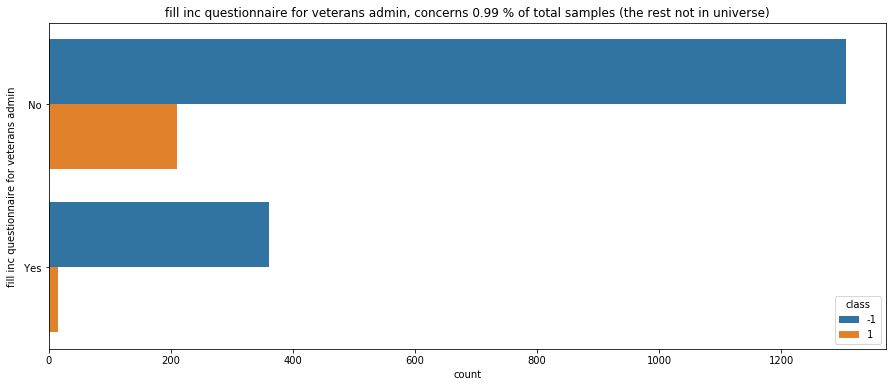

```
Ratio of classes for not in universe
Class -1: 99.07 % of total representatives not in universe for this feature
Class 1: 98.07 % of total representatives not in universe for this feature
-----------------------------------------------------------------------------------
```

```python
get_stats('fill inc questionnaire for veterans admin')
```

Once again, very few instances are concerned by this feature, we will ignore it.

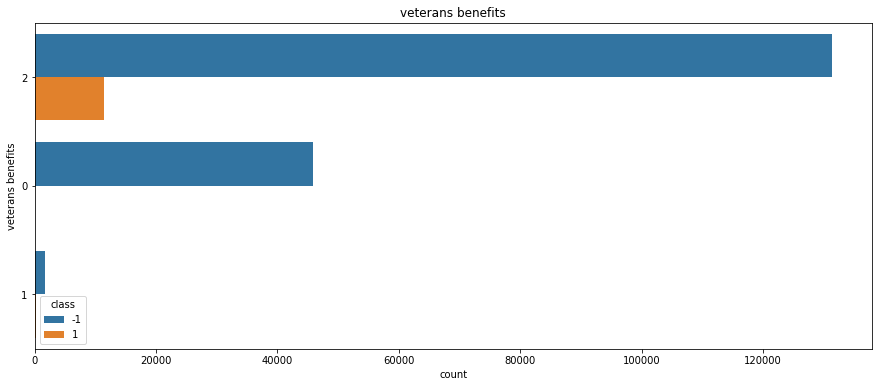

```python
get_stats('veterans benefits')
```

The values 0 and 1 seem to caracterize class 0, thus we will binarize this feature and keep it.

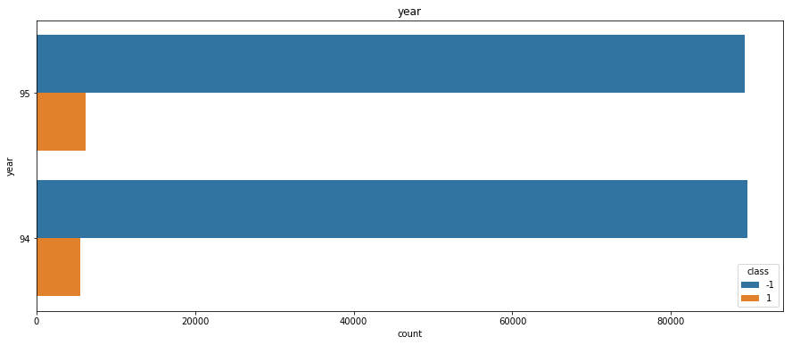

```python
get_stats('year')
```

Here we can see an equal distribution for both values, the feature is clearly non informative regarding the income, we will ignore it.

## 3. Feature extraction

To summarize the overall analysis, we need to write a function which will transform the train / test data frames into feature data frames, which afterwards could be treated by our model.

For the continuous variables, we can keep them as they are or transform them. As we have seen during our analysis, for some of those features, there are value areas which represent more one class than another (e.g. age < 18 is clearly class -1) and value areas which are 'neutral' (we seem to have both classes importantly present). Thus an idea to explore is to transform our features into ternary (sometimes binary) valued ones.

```python
def get_features(data):

    # After testing, the classifiers perform better when
    # the continuous variables are not transformed
    s00 = data['age'].map(lambda x: -1 if x<20 else 1) # child or not feature

    s0 = data['age']#.map(lambda x:\
                    #     -1 if x < 30 else 1 if 30<=x<70 else 0)
    s1 = data['wage per hour']#.map(lambda x:\
                    #     -1 if (x<1000) else 1)
    s2 = data['capital gain/loss']#.map(lambda x:\
                    #     -1 if (x < 500) else 1)
    s3 = data['dividends from stocks']#.map(lambda x:\
                    #     -1 if (x<100) else 1)
    s4 = data['num persons worked for employer']#.map(lambda x:\
                    #     -1 if x==0 else 0)
    s5 = data['weeks worked in year']#.map(lambda x:\
                    #     -1 if x < 27 else 1 if x==52 else 0)

    d1 = pd.get_dummies(data['major occupation code'])
    d2 = pd.get_dummies(data['major industry code'])

    l = [' Not in universe', ' Without pay', ' Never worked']
    s6 = data['class of worker'].map(lambda x: -1 if x in l else 0)

    s7 = data['race'].map(lambda x: -1 if x!=' White' else 1)
    s8 = data['sex'].map(lambda x:-1 if x!=' Male' else 1)
    s9 = data['citizenship'].map(lambda x: -1 if x!=' Native- Born in the United States' else 0)

    l = [' Bachelors degree(BA AB BS)', '  Masters degree(MA MS MEng MEd MSW MBA)',\
         ' Doctorate degree(PhD EdD)', '  Prof school degree (MD DDS DVM LLB JD)']
    s10 = data['education'].map(lambda x: -1 if x not in l else 0)
    s11 = data['tax filer status'].map(lambda x: -1 if x==' Nonfiler' else 0)

    l = [' Householder', ' Spouse of householder', ' Nonrelative of householder' ]
    s11 = data['detailed household summary in household'].map(lambda x: -1 if x not in l else 0)

    d3 = pd.get_dummies(data['marital status'])
    df = pd.concat([s00, s0, s1, s2, s3, s4, s5, s6, s7, s8, s9, s10, s11, d1, d2, d3], axis=1)
    return df
```

## 4. Predictive models

We will test and tweak several models for our prediction task. Since we transformed most of our features into binary yes or no, it seems natural to apply a decision tree model. We will use scikit-learns Random Forest classifier. In addition we will try using a Logistic Regression model and an SVM with a non linear kernel.

The class imbalance becomes a problem when building our predictive models. If we look at the accuracy of our predictor, it may be very good, but that does not mean that our model performs well. Let's illustrate this with an example. Let's consider just the 'age' feature, without modifications, and feed it into a Random Forest Classifier.

```python
X_train = pd.concat([cleaned_data['age']], axis=1)
y_train = np.array(cleaned_data['class'])
X_test = pd.concat([data_test['age']], axis=1)
y_test = np.array(data_test['class'])

clf = RandomForestClassifier(n_estimators=10)
clf = clf.fit(X_train, y_train)

scores = cross_val_score(clf, X_train , y_train)
print(scores.mean())

y_pred = clf.predict(X_test)
cm = confusion_matrix(y_test, y_pred)
print('Confusion matrix: \n', cm)
```

```
0.938827986936
Confusion matrix:
 [[93576     0]
 [ 6186     0]]
```

We obtain a predictive accuracy of 93,9% on the test set. This is misleading, as we can see on the confusion matrix, none of the instances from class 1 were correctly predicted, in fact no entry was attributed to class 1. Thus we must pay attention, and use other metrics than just the accuracy percentage to evaluate the quality of our model.

To evaluate the quality of our model we need to look at the ratio of true positive/negatives and false positive/negatives. Our use case has no particular sensitivity about the preference between ture positives and true negatives, unlike a clinical case where prediction errors one class can be more acceptable than on the other. Thus we would like an optimal precision on both classes.

Confusion matrix is a good visual indicator since we can see how well our model is performing in terms of precision and recall. Another tool that puts an emphasis on these metrics is the ROC curve, and the AUC metric.

**SKLEARN DEFINITION: By definition a confusion matrix $C$ is such that $C_{i, j}$ is equal to the number of observations known to be in group i but predicted to be in group j. Thus in binary classification, the count of true negatives is $C_{0,0}$, false negatives is $C_{1,0}$, true positives is $C_{1,1}$ and false positives is $C_{0,1}$**

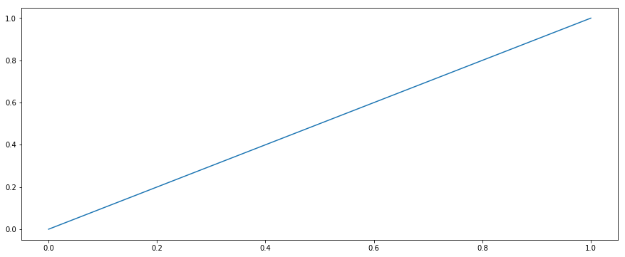

```
AUC =  0.5
F1 score =  0.0
```

```python
fpr,tpr,_ = roc_curve(y_test, y_pred)
plt.figure(figsize=(15,6))
plt.plot(fpr,tpr)
plt.show()
print('AUC = ', auc(fpr, tpr))
print('F1 score = ', f1_score(y_test, y_pred))
```

This is the ROC curve of the worst classifier we can get, it allows us to see what the predictive accuracy alone would not let us see, which is the real performance of our classifier when we have an imabalanced dataset. No F1 score can be extracted since no instance was classified as class 1.

### 4.1 Undersampling the majority class

Even if does not seem the best thing to do, we can heavily undersample the majority class to obtain a balanced dataset. The drawback is that we will end up with roughly 10-15% of the original dataset.

```python
s = cleaned_data['class'].value_counts()
n = dict(s)[1]

s0 = cleaned_data[cleaned_data['class']==-1]
ss = s0.sample(n)
s1 = cleaned_data[cleaned_data['class']==1]

X_reduced = pd.concat([ss, s1])
#Shuffle once again
X_reduced = X_reduced.sample(frac=1.)

X_train_red = get_features(X_reduced)
y_train_red = X_reduced['class']

X_test = get_features(data_test)
y_test = data_test['class']
```

#### a) Random Forests

Since most of the columns of our feature matrix come from a one hot encoding, in order to augment chances working with all the features we will tweak the n_estimators and max_depth features.

```python
for n_e in [25, 50, 75]:
    for m_d in [20, 25, 30]:
        t0 = time()
        clf = RandomForestClassifier(n_estimators=n_e, max_depth = m_d)
        clf = clf.fit(X_train_red, y_train_red)
        print('fitted (s): ', time()-t0)
        print('with n_estimators = %d and max_depth = %d' %(n_e, m_d))
        scores = cross_val_score(clf, X_train_red , y_train_red)
        print(scores.mean())
        t1 = time()
        y_pred = clf.predict(X_test)
        print('predicted (s): ', time()-t1)
        cm = confusion_matrix(y_test, y_pred)
        print('Confusion matrix: \n', cm)

        fpr_rf,tpr_rf,_ = roc_curve(y_test, y_pred)
        auc_rf = auc(fpr_rf, tpr_rf)
        print('AUC = ', auc_rf)
        print('F1 score = ', f1_score(y_test, y_pred))
        print('-------------------------------------------------------')
```

```
fitted (s):  0.6076231002807617
with n_estimators = 25 and max_depth = 20
0.866946565711
predicted (s):  0.5392816066741943
Confusion matrix:
 [[78006 15570]
 [  591  5595]]
AUC =  0.869036435018
F1 score =  0.409125808928
-------------------------------------------------------
fitted (s):  0.6856660842895508
with n_estimators = 25 and max_depth = 25
0.863386469331
predicted (s):  0.5712175369262695
Confusion matrix:
 [[78377 15199]
 [  656  5530]]
AUC =  0.865764982018
F1 score =  0.410923276983
-------------------------------------------------------
fitted (s):  0.6600456237792969
with n_estimators = 25 and max_depth = 30
0.860683921183
predicted (s):  0.6463127136230469
Confusion matrix:
 [[78303 15273]
 [  695  5491]]
AUC =  0.862217302148
F1 score =  0.407495361781
-------------------------------------------------------
fitted (s):  0.9983463287353516
with n_estimators = 50 and max_depth = 20
0.870077496068
predicted (s):  1.067749261856079
Confusion matrix:
 [[77921 15655]
 [  593  5593]]
AUC =  0.868420603383
F1 score =  0.407742217686
-------------------------------------------------------
```

[output cut: 35 more lines]

```
 [[78305 15271]
 [  619  5567]]
AUC =  0.868370891978
F1 score =  0.412004144464
-------------------------------------------------------
fitted (s):  1.8546826839447021
with n_estimators = 75 and max_depth = 30
0.863987058892
predicted (s):  1.807816982269287
Confusion matrix:
 [[78635 14941]
 [  654  5532]]
AUC =  0.867305195974
F1 score =  0.415019318054
-------------------------------------------------------
```

```python
for n_e in [75]:
    for m_d in [20]:
        t0 = time()
        clf = RandomForestClassifier(n_estimators=n_e, max_depth = m_d)
        clf = clf.fit(X_train_red, y_train_red)
        print('with n_estimators = %d and max_depth = %d' %(n_e, m_d))
        scores = cross_val_score(clf, X_train_red , y_train_red)
        print(scores.mean())

        y_pred = clf.predict(X_test)
        cm = confusion_matrix(y_test, y_pred)
        print('Confusion matrix: \n', cm)

        fpr_rf,tpr_rf,_ = roc_curve(y_test, y_pred)
        auc_rf = auc(fpr_rf, tpr_rf)
        print('AUC = ', auc_rf)
        print('F1 score = ', f1_score(y_test, y_pred))
        print('elapsed (s): ', time()-t0)
        print('-------------------------------------------------------')
```

```
with n_estimators = 75 and max_depth = 20
0.868662026485
Confusion matrix:
 [[77833 15743]
 [  567  5619]]
AUC =  0.870051916907
F1 score =  0.407942500363
elapsed (s):  6.9557249546051025
-------------------------------------------------------
```

#### b) Logistic Regression

We will use Logistic Regression CV since it internally applied a stratified K-fold cross validation to select the best penalty value.

```python
for penalty in ['l1', 'l2']:
    for cv in [None, 2, 4]:
        t0=time()

        if penalty=='l1': solver = 'liblinear'
        else: solver = 'lbfgs'

        clf = LogisticRegressionCV(fit_intercept=False, penalty=penalty, cv=cv, solver = solver)
        clf = clf.fit(X_train_red, y_train_red)
        print('fitted (s): ', time()-t0)
        print('with penalty = %s and cv = %s' %(penalty, str(cv)))
        scores = cross_val_score(clf, X_train_red , y_train_red)
        print(scores.mean())
        t1=time()
        y_pred = clf.predict(X_test)
        print('predicted (s): ', time()-t1)
        cm = confusion_matrix(y_test, y_pred)
        print('Confusion matrix: \n', cm)

        fpr_lr,tpr_lr,_ = roc_curve(y_test, y_pred)
        auc_lr = auc(fpr_lr, tpr_lr)
        print('AUC = ', auc_lr)
        print('F1 score = ', f1_score(y_test, y_pred))
        print('elapsed (s): ', time()-t0)
        print('-------------------------------------------------------')
```

```
fitted (s):  2.8272087574005127
with penalty = l1 and cv = None
0.85935443936
predicted (s):  0.04757404327392578
Confusion matrix:
 [[77041 16535]
 [  681  5505]]
AUC =  0.856605707591
F1 score =  0.390065896691
elapsed (s):  7.443262100219727
-------------------------------------------------------
fitted (s):  1.2871997356414795
with penalty = l1 and cv = 2
0.859311517237
predicted (s):  0.06205272674560547
Confusion matrix:
 [[77027 16549]
 [  673  5513]]
AUC =  0.857177523488
F1 score =  0.390328518833
elapsed (s):  4.115435600280762
-------------------------------------------------------
fitted (s):  3.706702470779419
with penalty = l1 and cv = 4
0.859311561396
predicted (s):  0.053606510162353516
Confusion matrix:
 [[77042 16534]
 [  680  5506]]
AUC =  0.856691878516
F1 score =  0.390136753348
elapsed (s):  11.985438823699951
-------------------------------------------------------
fitted (s):  10.6086745262146
with penalty = l2 and cv = None
0.855408242593
predicted (s):  0.06758856773376465
Confusion matrix:
 [[76397 17179]
 [  691  5495]]
```

[output cut: 11 more lines]

```
AUC =  0.850571996252
F1 score =  0.373144924107
elapsed (s):  13.224128007888794
-------------------------------------------------------
fitted (s):  18.848788261413574
with penalty = l2 and cv = 4
0.855108350759
predicted (s):  0.05959606170654297
Confusion matrix:
 [[76282 17294]
 [  688  5498]]
AUC =  0.851984386805
F1 score =  0.379460280213
elapsed (s):  48.13184976577759
-------------------------------------------------------
```

```python
for penalty in ['l1']:
    for cv in [4]:
        t0=time()

        if penalty=='l1': solver = 'liblinear'
        else: solver = 'lbfgs'

        clf = LogisticRegressionCV(fit_intercept=False, penalty=penalty, cv=cv, solver = solver)
        clf = clf.fit(X_train_red, y_train_red)
        print('with penalty = %s and cv = %s' %(penalty, str(cv)))
        scores = cross_val_score(clf, X_train_red , y_train_red)
        print(scores.mean())

        y_pred = clf.predict(X_test)
        cm = confusion_matrix(y_test, y_pred)
        print('Confusion matrix: \n', cm)

        fpr_lr,tpr_lr,_ = roc_curve(y_test, y_pred)
        auc_lr = auc(fpr_lr, tpr_lr)
        print('AUC = ', auc_lr)
        print('F1 score = ', f1_score(y_test, y_pred))
        print('elapsed (s): ', time()-t0)
        print('-------------------------------------------------------')
```

```
with penalty = l1 and cv = 4
0.859268628234
Confusion matrix:
 [[77051 16525]
 [  678  5508]]
AUC =  0.856901623121
F1 score =  0.390375279067
elapsed (s):  10.292328119277954
-------------------------------------------------------
```

#### c) SVC

```python
for C in [0.01, 1., 10]:
    t0 = time()
    clf = SVC(C = C)
    clf = clf.fit(X_train_red, y_train_red)
    print('fitted (s): ', time()-t0)
    print('with C = %s ' %(str(C)))
    scores = cross_val_score(clf, X_train_red , y_train_red)
    print(scores.mean())
    t1=time()
    y_pred = clf.predict(X_test)
    print('predicted (s): ', time()-t1)
    cm = confusion_matrix(y_test, y_pred)
    print('Confusion matrix: \n',cm)

    fpr_svc,tpr_svc,_ = roc_curve(y_test, y_pred)
    auc_svc = auc(fpr_svc, tpr_svc)
    print('AUC = ', auc_svc)
    print('F1 score = ', f1_score(y_test, y_pred))
    print('elapsed (s): ', time()-t0)
    print('-------------------------------------------------------')
```

```
fitted (s):  66.88487029075623
with C = 0.01
0.763961435886
predicted (s):  158.0487401485443
Confusion matrix:
 [[55965 37611]
 [  215  5971]]
AUC =  0.781657058767
F1 score =  0.2399533837
elapsed (s):  348.1851155757904
-------------------------------------------------------
fitted (s):  121.82826614379883
with C = 1.0
0.839495660649
predicted (s):  126.20710468292236
Confusion matrix:
 [[73407 20169]
 [  570  5616]]
AUC =  0.846160207584
F1 score =  0.351318382284
elapsed (s):  397.63901352882385
-------------------------------------------------------
fitted (s):  170.1715269088745
with C = 10
0.843441791177
predicted (s):  118.25964093208313
Confusion matrix:
 [[75028 18548]
 [  644  5542]]
AUC =  0.848840368513
F1 score =  0.366098559915
elapsed (s):  528.9480857849121
-------------------------------------------------------
```

For small values of C, the classifier performs the best for class 1 but with very low precision for class -1. The overall execution time is superior to what we have seen before. In fact we obtain similar results much faster with Logistic regression or Random forests.

Let us visualize the ROC curves for the best configurations kepts from the three models.

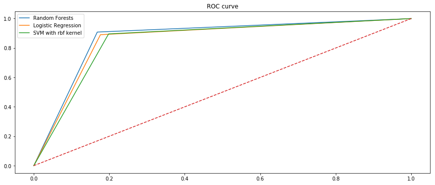

```python
plt.figure(figsize=(15,6))
plt.title('ROC curve')
plt.plot(fpr_rf,tpr_rf, label='Random Forests')
plt.plot(fpr_lr,tpr_lr, label='Logistic Regression')
plt.plot(fpr_svc,tpr_svc, label='SVM with rbf kernel')
plt.plot([0,1], [0,1], linestyle='--')
plt.legend()
plt.show()
```

With the respect to the ROC curve here, the Random Forest classifier performs the best on the data. It has the highest AUC and F1 score, and is more precise in the predictions. This is valid in the current setting, given our choice of feature design.

### 4.2 Oversampling the minority class

Another radical strategy could be completely oversampling the minority class to raise its number of samples to the number of representatives in the majority class. This augments the size of our dataset condsiderably, thus the computational complexity. We will try to use the SMOTE algorithm from the imbalanced-learn API (http://contrib.scikit-learn.org/imbalanced-learn/stable/api.html).

```python
from imblearn.over_sampling import SMOTE
from collections import Counter
```

```python
X_train = get_features(cleaned_data)
y_train = cleaned_data['class']

X_test = get_features(data_test)
y_test = data_test['class']

print('Original dataset shape {}'.format(Counter(y_train)))
sm = SMOTE(random_state=42)
X_train_over, y_train_over = sm.fit_sample(X_train, y_train)
print('Resampled dataset shape {}'.format(Counter(y_train_over)))
```

```
Original dataset shape Counter({-1: 178904, 1: 11657})
Resampled dataset shape Counter({1: 178904, -1: 178904})
```

#### a) Random Forests

```python
n_e = 20
m_d = 25
t0 = time()
clf = RandomForestClassifier(n_estimators=n_e, max_depth = m_d)
clf = clf.fit(X_train_over, y_train_over)
print('fitted (s): ', time()-t0)
print('with n_estimators = %d and max_depth = %d' %(n_e, m_d))
scores = cross_val_score(clf, X_train_over , y_train_over)
print(scores.mean())
t1 = time()
y_pred = clf.predict(X_test)
print('predicted (s): ', time()-t1)
cm = confusion_matrix(y_test, y_pred)
print('Confusion matrix: \n', cm)

fpr_rf,tpr_rf,_ = roc_curve(y_test, y_pred)
auc_rf = auc(fpr_rf, tpr_rf)
print('AUC = ', auc_rf)
print('F1 score = ', f1_score(y_test, y_pred))
print('elapsed (s): ', time()-t0)
print('-------------------------------------------------------')
```

```
fitted (s):  16.59960126876831
with n_estimators = 20 and max_depth = 25
0.957639377983
predicted (s):  0.5350136756896973
Confusion matrix:
 [[89861  3715]
 [ 2618  3568]]
AUC =  0.768542970555
F1 score =  0.529809191477
elapsed (s):  47.8351035118103
-------------------------------------------------------
```

Oversampling the minority class with the SMOTE algorithm worsens considerably the results of the Random Forest Classifier. We have an AUC inferior to what we have obtained before but a higher F1 score. This is because we have much less error on predictions for class -1, however the errors on the other class have considerably risen.

#### b) Logistic Regression

```python
t0=time()
clf = LogisticRegressionCV(cv=4)
clf = clf.fit(X_train_over, y_train_over)
print('fitted (s): ', time()-t0)
scores = cross_val_score(clf, X_train_over , y_train_over)
print(scores.mean())
t1=time()
y_pred = clf.predict(X_test)
print('predicted (s): ', time()-t1)
cm = confusion_matrix(y_test, y_pred)
print('Confusion matrix: \n', cm)

fpr_lr,tpr_lr,_ = roc_curve(y_test, y_pred)
auc_lr = auc(fpr_lr, tpr_lr)
print('AUC = ', auc_svc)
print('F1 score = ', f1_score(y_test, y_pred))
print('elapsed (s): ', time()-t0)
```

```
fitted (s):  212.84901571273804
0.869905095659
predicted (s):  0.055063724517822266
Confusion matrix:
 [[78126 15450]
 [  753  5433]]
AUC =  0.848840368513
F1 score =  0.401418596919
elapsed (s):  668.9564332962036
```

Once again we have almost no improvement, whereas the computation time is considerably increased.

#### c) SVC

[output not shown]

The SVM takes way too much time to train and predict, so the execution was stopped. The use of SMOTE algorithm does not make our results better.

## Conclusion

The best model we got so far was the Random Forest Classifier trained on the reduced data set. For future improvement, the feature design should be studied more thoroughly since many possibilities were not explored in this notebook:

```
     - Study the performance of the model by adding or removing some features
     - Study the performance of the model by simplifying or not some features
     - Explore more thoroughly the correlation between all the different features
     - Try other over sampling / under sampling methods (the imblearn library provides different methods that would be interesting to test, different oversampling methods and also some combined over/under sampling methods)
     - Since the resulting feature matrix is sparse, we could try  some dimensionality reduction techniques such as PCA or TSVD
```